# Stage 3: Preforming the Analysis

```python
import csv as csv
import numpy as np
import pandas as pd
import matplotlib.pyplot as plt
import seaborn as sns
from scipy import stats
from scipy import spatial
import statsmodels.api as sm

import warnings
warnings.filterwarnings('ignore')
```

# Data Importing, Cleaning and Processing

After importing the data and adding in column names and ensuring the numerical data was imported as the correct type, the data cleaning stages occured. The first step was to remove any columns that already appeared to be uniformative. There were six different columsn dropped: the compeititon reference, the application number, the CRN number (compeititon reference number), the competition title, the postcode and the address LEP (local enterprise partnership) of the project. They were dropped because they were either unique number identifiers used by Innovate UK (competition reference, application number, CRN), they contained too granular information that is also captured in another column (postcode and address LEP's information is captured in the address region column) or they contained duplicate information (comeptition title holds the same information as programme title).

```python
#import the raw dataset downloaded from:
#https://www.gov.uk/government/publications/innovate-uk-funding-competition-winners-2017
grants = pd.read_excel('fundedprojects_2014_2018.xlsx')

#Add the column titles that come from the raw data file
grants.columns = ['CompetitionReference', 'CompetitionTitle', 'ProgrammeTitle', 'Sector',
                  'ApplicationNumber', 'ProjectNumber', 'ProjectTitle', 'PublicDescription', 'CompetitionYear',
                 'InnovateUKType', 'ParticipantName','IsLeadParticipant', 'CRN', 'StartDate', 'EndDate',
                  'GrantOffered', 'TotalCost', 'ActualSpend', 'WithdrawnStatus', 'ProjectStatus', 'EnterpriseSize',
                 'Postcode', 'AddressRegion', 'AddressLEP', 'ISCF']

#ensure the number columns are read fully as floats
grants['GrantOffered'] = grants['GrantOffered'].astype('float64')
grants['TotalCost'] = grants['TotalCost'].astype('float64')
grants['ActualSpend'] = grants['ActualSpend'].astype('float64')

#drop columns that already look uninformative for analysis or modeling
#as they are either random number identifiers used by InnovateUK (eg: competition reference, application number, CRN),
#contain duplicate information (eg: compeition title is already seen in programme title),
# or have too granular information to be informative (eg: postcode, addressLEP)
grants = grants.drop(['CompetitionReference','ApplicationNumber', 'CRN','CompetitionTitle',
                       'Postcode', 'AddressLEP', ],1)

grants.head()
```

|  | ProgrammeTitle | Sector | ProjectNumber | ProjectTitle | PublicDescription | CompetitionYear | InnovateUKType | ParticipantName | IsLeadParticipant | StartDate | EndDate | GrantOffered | TotalCost | ActualSpend | WithdrawnStatus | ProjectStatus | EnterpriseSize | AddressRegion | ISCF |
| --- | --- | --- | --- | --- | --- | --- | --- | --- | --- | --- | --- | --- | --- | --- | --- | --- | --- | --- | --- |
| 0 | Legacy - CR&D | Manufacturing & Materials | 140092 | HISTORIC - High Integrity Real Time Systems (H... | Awaiting Public Project Summary | 2003/04 | Collaborative R&D | The University of York | Yes | 2002-10-01 | 2007-09-30 | 0.0 | 0.0 | 77052.88 | Active | Closed | Academic | Yorkshire and The Humber | NaN |
| 1 | Legacy - Energy | Infrastructure Systems | 210010 | HISTORIC - Metering & Monitoring of Domestic E... | Awaiting Public Project Summary | 2004/05 | Collaborative R&D | Beama Power Limited | Yes | 2003-10-01 | 2005-09-30 | 0.0 | 39789.0 | 0.00 | Withdrawn | Closed | Unknown | London | NaN |
| 2 | Legacy - CR&D | Manufacturing & Materials | 140089 | HISTORIC - Light Alloy Castings in Airframe St... | Awaiting Public Project Summary | 2003/04 | Collaborative R&D | Castings Technology International | Yes | 2003-11-01 | 2007-10-31 | 0.0 | 0.0 | 31656.89 | Active | Closed | Large | Yorkshire and The Humber | NaN |
| 3 | Legacy - CR&D | Manufacturing & Materials | 210007 | An Automotive Class MEA | Awaiting Public Project Summary | 2003/04 | Collaborative R&D | Mast Carbon Technology Limited | No | 2004-04-01 | 2007-06-30 | 0.0 | 0.0 | 0.00 | Active | Closed | Small | North West | NaN |
| 4 | Legacy - CR&D | Manufacturing & Materials | 210007 | An Automotive Class MEA | Awaiting Public Project Summary | 2003/04 | Collaborative R&D | Primasil Silicones Limited | No | 2004-04-01 | 2007-06-30 | 0.0 | 0.0 | 0.00 | Active | Closed | Medium | West Midlands | NaN |

## Discovering where are the missing values

```python
#find out what are the datatypes of each column and how many data-points there are in the dataset
print(grants.info())
print('\n')

#get the number of null values for each column
#by subtracting the length of the dataframe from the number of non-NA cells for each column
print('Number of missing values in each column: \n',  len(grants) - grants.count())
print('\n')


#get the percentage of null values for each column
#by dividing the number of null values for each column by the total amount of rows and multiplying by 100
print('\nPercentage of missing values in each column:\n',  (len(grants) - grants.count() ) / len(grants) * 100)
```

```
<class 'pandas.core.frame.DataFrame'>
RangeIndex: 32808 entries, 0 to 32807
Data columns (total 19 columns):
ProgrammeTitle       32808 non-null object
Sector               32801 non-null object
ProjectNumber        32808 non-null int64
ProjectTitle         32808 non-null object
PublicDescription    32808 non-null object
CompetitionYear      32808 non-null object
InnovateUKType       32798 non-null object
ParticipantName      32808 non-null object
IsLeadParticipant    32808 non-null object
StartDate            31449 non-null datetime64[ns]
EndDate              31449 non-null datetime64[ns]
GrantOffered         31449 non-null float64
TotalCost            31444 non-null float64
ActualSpend          31449 non-null float64
WithdrawnStatus      32808 non-null object
ProjectStatus        32808 non-null object
EnterpriseSize       32808 non-null object
AddressRegion        32808 non-null object
ISCF                 1305 non-null object
dtypes: datetime64[ns](2), float64(3), int64(1), object(13)
memory usage: 4.8+ MB
None


Number of missing values in each column:
 ProgrammeTitle           0
Sector                   7
ProjectNumber            0
ProjectTitle             0
PublicDescription        0
CompetitionYear          0
InnovateUKType          10
ParticipantName          0
IsLeadParticipant        0
StartDate             1359
EndDate               1359
GrantOffered          1359
```

[output cut: 17 more lines]

```
CompetitionYear       0.000000
InnovateUKType        0.030480
ParticipantName       0.000000
IsLeadParticipant     0.000000
StartDate             4.142282
EndDate               4.142282
GrantOffered          4.142282
TotalCost             4.157523
ActualSpend           4.142282
WithdrawnStatus       0.000000
ProjectStatus         0.000000
EnterpriseSize        0.000000
AddressRegion         0.000000
ISCF                 96.022312
dtype: float64
```

## Handling Missing Values

The first missing value column to deal with was the ISCF, or industrial strategy fund challenge, column. The values in this column were either blank or 'yes', indicating that the column contains information on if the project is apart of the fund or not. I decided to fill each of the null values with 'no', as this would mean they were not in the fund, providing informative information for analysis and ensuring there were no missing values left in the column.

Next, I noticed that there was around the same amount of values were missing from the start date, end date, grant offered, total cost, and actual spend columns. I thought this might be because the missing values all came from the same rows, or projects. To determine this, I subsetted the data to only have the rows where the grant offered column value was null. I then got the sum of the null values in each column in this subset and compared them to the number of missing values from the full data-set. These numbers overlapped, except 1 more innovate uk type was missing and 5 more total cost values.

As 1,359 rows have 7 column values missing, and they only make up 4% of my data-set, I decided it was better to remove them entirely then attempt any imputation, as there is not a clear-cut way to input these values (as most are categorical) and doing it too many times leads to a high risk of changing my final results. Therefore, I removed all rows with a missing value. This resulted in loss of a total of 1,365 data-points which is 4.16% of the data. The resulting data-set has 31,443 rows.

```python
#Fill in the missing ISCF values with a 'No' value as this indicates that these projects are not apart of the challenge
grants['ISCF'] = grants['ISCF'].fillna(value = 'No')


##Explore to see if the applications which do not have a grant offer are the same as those without
#a start and end date and the other missing features

#First create a new data frame which only has projects with null grant values
grants_null = grants[grants['GrantOffered'].isnull()]

#Then, compare the amount of missing values for each column in the new data sub-set and compare them the full dataset
print('Grants_null number of missing values of :\n', len(grants_null) - grants_null.count())
print('\n')
print('Full dataset number of missing values of : \n',  len(grants) - grants.count())
print('\n')

#Answer is basically yes, as there is overlap in both dataframe missing value counts
#except that there is one more misisng innovateuktype value and 5 more missing totalcost values
#therefore decide to remove all null grants from main dataframe
grants = grants.dropna()
grants.info()
```

```
Grants_null number of missing values of :
 ProgrammeTitle          0
Sector                  7
ProjectNumber           0
ProjectTitle            0
PublicDescription       0
CompetitionYear         0
InnovateUKType          9
ParticipantName         0
IsLeadParticipant       0
StartDate            1359
EndDate              1359
GrantOffered         1359
TotalCost            1359
ActualSpend          1359
WithdrawnStatus         0
ProjectStatus           0
EnterpriseSize          0
AddressRegion           0
ISCF                    0
dtype: int64


Full dataset number of missing values of :
 ProgrammeTitle          0
Sector                  7
ProjectNumber           0
ProjectTitle            0
PublicDescription       0
CompetitionYear         0
InnovateUKType         10
ParticipantName         0
IsLeadParticipant       0
StartDate            1359
EndDate              1359
GrantOffered         1359
TotalCost            1364
ActualSpend          1359
WithdrawnStatus         0
ProjectStatus           0
```

[output cut: 15 more lines]

```
InnovateUKType       31443 non-null object
ParticipantName      31443 non-null object
IsLeadParticipant    31443 non-null object
StartDate            31443 non-null datetime64[ns]
EndDate              31443 non-null datetime64[ns]
GrantOffered         31443 non-null float64
TotalCost            31443 non-null float64
ActualSpend          31443 non-null float64
WithdrawnStatus      31443 non-null object
ProjectStatus        31443 non-null object
EnterpriseSize       31443 non-null object
AddressRegion        31443 non-null object
ISCF                 31443 non-null object
dtypes: datetime64[ns](2), float64(3), int64(1), object(13)
memory usage: 4.8+ MB
```

# Investigating the dependent variable: Grant Offered

My first qustion to answer is what are the biggest determinants of a project’s grant value offered by Innovate UK based on its application, and can we predict how much money a project will receive based on its application? To do this I need to understand the hidden structure behind the grant offered values and make sure that they are fit for modeling and analysis.

## Initial Investigation and Descriptive Statistics

First, I printed the counts of each of the different values in the grant offered column. This showed a wide-spread and sparsity, with many counts equal to 1. I also noticed that there were 1,721 0 valued grants. While the grants included in the dataset were successfully accepted, the actual grant value amount for funding was still up for consideration. These zero-valued entries could be because the grants eventually did not recieve any money from Innovate UK. I decided to remove these 0-valued grant projects as I want to investigate applications which have been provided with money. Removal will also ensure a smoother data analysis flow as many transformations and modeling algorithms do not handle zero-values well. I have subsetted these 0-valued grants into another dataframe however as they could be useful for comparison further in the analysis. The removal of these 1,721 rows reduced the data-set by 5.47%, leaving a 29,722 row long data-frame

Once I removed the zero-values I calculated some descriptive statistics of the grant offered values to see what is the range of values and quanitiles I will be modeling on. I also plotted a histogram to visualize the frequency of each value and a boxplot to visualize the quantiles more clearly.

```python
print(grants['GrantOffered'].value_counts()) #print counts of each value in the grantoffered column
```

```
5000.0        3247
0.0           1721
25000.0        271
100000.0       255
15000.0        150
250000.0       131
50000.0        125
20000.0        115
1500.0          98
150000.0        93
24750.0         77
10000.0         69
72600.0         60
30000.0         56
600.0           54
24000.0         51
3000.0          46
8000.0          42
60000.0         41
75000.0         39
45000.0         37
16000.0         35
23100.0         34
21000.0         34
40000.0         34
24975.0         33
24999.0         31
42000.0         31
35000.0         31
90000.0         30
              ...
54924.0          1
166672.0         1
74492.0          1
232058.0         1
141816.0         1
77806.0          1
36158.0          1
240513.0         1
189102.0         1
183631.0         1
92793.0          1
58850.0          1
344116.0         1
161003.0         1
59686.0          1
44347.0          1
15814.0          1
1222500.0        1
157750.0         1
136429.0         1
172286.0         1
70322.0          1
42211494.0       1
372056.0         1
54133.0          1
136431.0         1
107605.0         1
9551.0           1
7516.0           1
28082.0          1
Name: GrantOffered, Length: 21529, dtype: int64
```

```python
#subseting the zero-valued grantOffered rows into a new dataframe called grants_zero
grants_zero = grants[grants['GrantOffered'] == 0]
#removing all the zero-valued rows from the main grants dataframe
grants = grants[grants['GrantOffered'] != 0]


#See that the dataset has reduced by 1,721 rows, or 5.47%, resulting in a 29,722 row long data-frame
grants.info()
```

```
<class 'pandas.core.frame.DataFrame'>
Int64Index: 29722 entries, 1726 to 31448
Data columns (total 19 columns):
ProgrammeTitle       29722 non-null object
Sector               29722 non-null object
ProjectNumber        29722 non-null int64
ProjectTitle         29722 non-null object
PublicDescription    29722 non-null object
CompetitionYear      29722 non-null object
InnovateUKType       29722 non-null object
ParticipantName      29722 non-null object
IsLeadParticipant    29722 non-null object
StartDate            29722 non-null datetime64[ns]
EndDate              29722 non-null datetime64[ns]
GrantOffered         29722 non-null float64
TotalCost            29722 non-null float64
ActualSpend          29722 non-null float64
WithdrawnStatus      29722 non-null object
ProjectStatus        29722 non-null object
EnterpriseSize       29722 non-null object
AddressRegion        29722 non-null object
ISCF                 29722 non-null object
dtypes: datetime64[ns](2), float64(3), int64(1), object(13)
memory usage: 4.5+ MB
```

```
Mean: 246526.21216607228
Standard Deviation: 1756170.8914506582
Median: 71000.0
Mode: 0    5000.0
dtype: float64
Min: 1.0
Max: 79200000.0
Range: 79199999.0
IQR: 131664.25

Quantiles:
 0.10      5000.00
0.25     22132.00
0.50     71000.00
0.75    153796.25
0.90    331391.70
Name: GrantOffered, dtype: float64
```

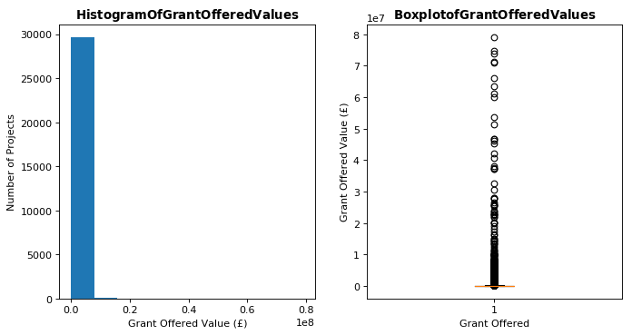

```python
## Printing Descriptive Statistics of the grants offered column
meanGrant = grants['GrantOffered'].mean()
print('Mean:' , meanGrant)

sdGrant = grants['GrantOffered'].std()
print('Standard Deviation:', sdGrant)

medianGrant = grants['GrantOffered'].median()
print('Median:', medianGrant)

modeGrant = grants['GrantOffered'].mode()
print('Mode:', modeGrant)

print('Min:', grants['GrantOffered'].min())
print('Max:', grants['GrantOffered'].max())

rangeGrant = grants['GrantOffered'].max() - grants['GrantOffered'].min()
print('Range:' , rangeGrant)

IQRGrant = grants['GrantOffered'].quantile(0.75) - grants['GrantOffered'].quantile(0.25)
print('IQR:' , IQRGrant, '\n')

print('Quantiles:\n', grants['GrantOffered'].quantile(q = [0.10, 0.25,0.5,0.75,0.9]))

#plot a histogram and a boxplot of the grant offered values side by side
%matplotlib inline
fig=plt.figure(figsize=(10,5), dpi=80, facecolor='w', edgecolor='k')
plt.subplot(1, 2, 1)
plt.hist(grants['GrantOffered'])
plt.xlabel('Grant Offered Value (£)')
plt.ylabel('Number of Projects')
plt.title(r"$\bf{Histogram Of Grant Offered Values}$")
plt.subplot(1, 2, 2)
plt.boxplot(grants['GrantOffered'])
plt.xlabel('Grant Offered')
plt.ylabel("Grant Offered Value (£)")
plt.title(r"$\bf{Boxplot of Grant Offered Values}$")
plt.show()
```

## Log Normalising the Grant Offered Values

```python
#make a new column containing normalised grant values for easy reference
grants['NormalisedGrants'] = grants['GrantOffered'].apply(np.log)
#as well make a normalised cost column for easy comparison
grants['NormalisedCost'] = grants['TotalCost'].apply(np.log)
#and a normalised actual cost colmn
grants['NormalisedSpend'] = grants['ActualSpend'].apply(np.log)

#printing the new descriptive quantile statistics for the normalised values to see
#the new data values and their spread
print("Log Transformed Grant Values: \n", grants['NormalisedGrants'].quantile(q = [0.10, 0.25,0.5,0.75,0.9]))
```

```
Log Transformed Grant Values:
 0.10     8.517193
0.25    10.004780
0.50    11.170435
0.75    11.943384
0.90    12.711056
Name: NormalisedGrants, dtype: float64
```

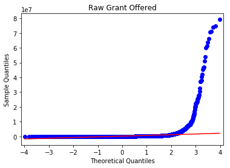

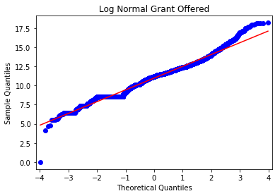

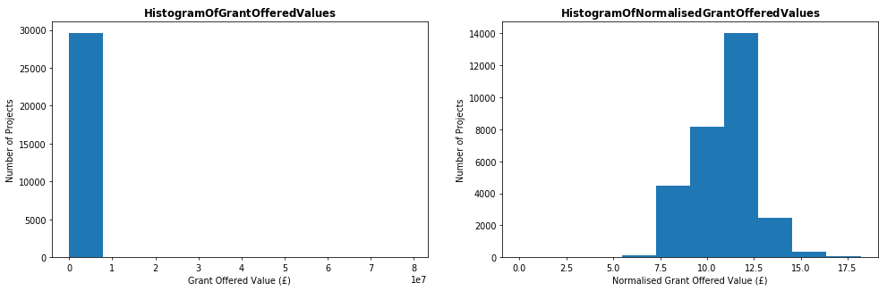

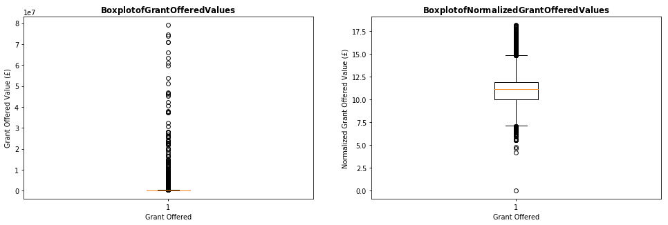

```python
## Visualizing the transformation
%matplotlib inline
#plt.style.use('ggplot')

#Plot the qqplot of the raw grant value data
fig=plt.figure(figsize=(10, 5), dpi=70, facecolor='w', edgecolor='k')
fig2 = sm.qqplot(grants['GrantOffered'], stats.norm, line = 'r') #qqplot of raw grant values
plt.title('Raw Grant Offered')
plt.show()

#Plot the qqplot of the log-normalized transformed grant value data
fig3 = sm.qqplot(grants['NormalisedGrants'], stats.norm, line = 'r') #qqplot of normalized grant values
plt.title('Log Normal Grant Offered')
plt.show()

#Plot the histogram of the raw grant values and normalized grant vales side by side
fig=plt.figure(figsize=(17, 5), dpi=70, facecolor='w', edgecolor='k')
plt.subplot(1, 2, 1)
plt.hist(grants['GrantOffered']) #histogram of raw grant values
plt.xlabel('Grant Offered Value (£)')
plt.ylabel('Number of Projects')
plt.title(r"$\bf{Histogram Of Grant Offered Values}$")
plt.subplot(1, 2, 2)
plt.hist(grants['NormalisedGrants']) #histogram of normalized grant values
plt.xlabel('Normalised Grant Offered Value (£)')
plt.ylabel('Number of Projects')
plt.title(r"$\bf{Histogram Of Normalised Grant Offered Values}$")
plt.show()

#Plot the raw and normalized grant value boxplots side by side
fig=plt.figure(figsize=(17, 5), dpi=70, facecolor='w', edgecolor='k')
plt.subplot(1, 2, 1)
plt.boxplot(grants['GrantOffered']) #raw value boxplot
plt.xlabel('Grant Offered')
plt.ylabel("Grant Offered Value (£)")
plt.title(r"$\bf{Boxplot of Grant Offered Values}$")
plt.subplot(1, 2, 2)
plt.boxplot(grants['NormalisedGrants']) #boxplt of normalized grant values
plt.xlabel('Grant Offered')
plt.ylabel("Normalized Grant Offered Value (£)")
plt.title(r"$\bf{Boxplot of Normalized Grant Offered Values}$")
plt.show()
```

## GrantOffered Outlier Detection

I noticed that in the log-transformed boxplot there was still a lot of outliers both above the IQR upper bound and below the IQR lower bound. To investigate this further, I ploted the normalised grant offered values against the normalised total cost values as well as against sector. In both these plots I also saw values which looked like outliers. It is best to remove outliers as it will help make my predictive model stronger as the pattern in the grant offered values will not be diluted by the outliers. To detect the outliers I used the log-normalized grant offered values as it will reduce the amount of outliers found (as well as ensure the distribution is maintained) as the raw grant offered boxplot is outliers only.

I investigated three different cut-off values for detecting outliers. The first was finding points whose abolute value difference from the mean were twice the standard deviation. The second was finding points whose abolute value difference from the mean were three times the standard deviation. The third was finding values which were within 1.5 times the first quartile and the third quartile of the data. To visualize which points were marked as outliers I used a scatter plot of normalised total cost and grant values and then colored the rows marked as outliers in orange and the normal values as grey.

I decided to use the third method, or the IQR method, as it uses more 'robust' statistics than standard deviation and will help to centralize and reduce my dataset without removing the interesting information or removing too many data-points.

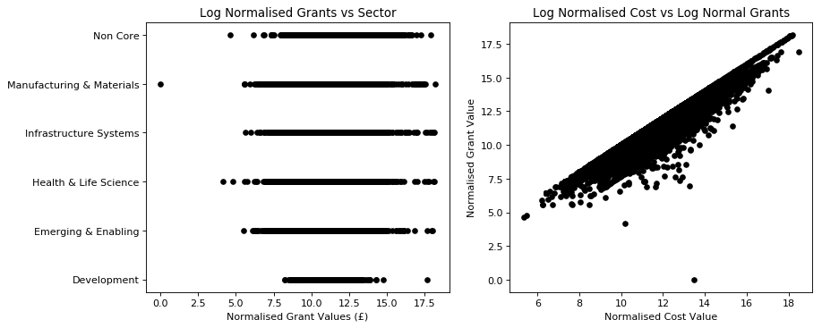

```python
# Visualize where outliers might be in the distribution by ploting the grant values in each sector group and against
#the cost value

fig=plt.figure(figsize=(12,5), dpi=80, facecolor='w', edgecolor='k')
plt.subplot(1, 2, 1)
plt.scatter(grants.NormalisedGrants, grants.Sector, linewidth=0, color = 'k')
plt.xlabel('Normalised Grant Values (£)')
plt.title('Log Normalised Grants vs Sector')
plt.subplot(1, 2, 2)
plt.scatter(grants.NormalisedCost,grants.NormalisedGrants, linewidth=0, color = 'k')
plt.xlabel('Normalised Cost Value')
plt.ylabel('Normalised Grant Value')
plt.title('Log Normalised Cost vs Log Normal Grants')
plt.show()

#Can already see some values which can be marked as outliers as they are outside the general trend of value ranges
```

```python
#calculate the mean and standard deviation of the normalised grants to be used to identify outliers
meanGrantNormalised = grants['NormalisedGrants'].mean()
sdGrantNormalised = grants['NormalisedGrants'].std()

#Make a new column in the grants dataframe which labels the row as an outlier or not using the FIRST technique
#which says an outlier is a value whose absolute difference from the mean is larger than twice the standard deviation
#Outliers are marked as 1 and non-outliers are marked as zero
grants['Outlier1'] = np.where(abs(grants['NormalisedGrants'] - meanGrantNormalised) > 2 * sdGrantNormalised, 1,0)

#Calculate how many datapoints are outliers (1) and non-outliers (0)
print(grants['Outlier1'].value_counts()) #There are 1,023 outliers in the dataset or
```

```
0    28699
1     1023
Name: Outlier1, dtype: int64
```

```python
#Do the same steps as above but make a column to mark the outliers based on the SECOND technique
#which labels values as outliers when their absolite difference from the mean is
#larger than three times the standard deviation

grants['Outlier2'] = np.where(abs(grants['NormalisedGrants'] - meanGrantNormalised) > 3 * sdGrantNormalised, 1,0)

#See how many outliers and non-outliers there are based on technique 2
#there is a LARGE reduction in the amount of outliers
#from 1023 to 148
print(grants['Outlier2'].value_counts())
```

```
0    29574
1      148
Name: Outlier2, dtype: int64
```

```python
#Do the same steps as above but make a column to mark the outliers based on the THIRD technique, or the IQR method
#which labels values as outliers when they are either 1.5 times the IQR below the first quartile
#or 1.5 time the IQR above the third quartile

#calculate the 1st and third quartile
quartile_1, quartile_3 = np.percentile(grants['NormalisedGrants'], [25, 75])
#calculate the iqr
iqr = quartile_3 - quartile_1
#calculate the lower and upper bounds of the value range
lower_bound = quartile_1 - (iqr * 1.5)
upper_bound = quartile_3 + (iqr * 1.5)

#create a new column which labels the rows as either outlier (1) or not (0) based on the IQR method
grants['Outlier3'] = np.where((grants['NormalisedGrants']> upper_bound) | (grants['NormalisedGrants'] < lower_bound), 1,0)

#See how many outliers and non-outliers there are based on technique 3
#there is an increase of 274 outliers found by method 3 vs method 2 (422 vs 148)
#but there is still a large reduction compared to method 1

print(grants['Outlier3'].value_counts())
```

```
0    29300
1      422
Name: Outlier3, dtype: int64
```

[figure not shown]

```python
#Color code all the values labeled as outliers in orange on a scatterplot to visualize where they are and to
#help me decide which technique is best to use
#technique 2 and 3 look the same visually though technique 3 identified 274 more points
#I decided to go with the IQR method as it uses more 'robust' statistics than standard deviation and will
#help to centralize and reduce my dataset without removing the interesting information

value=(grants['Outlier1']==1)
grants['color1']= np.where( value==True , "#D06B36", "#B9BCC0")
value2=(grants['Outlier2']==1)
grants['color2']= np.where( value2==True , "#D06B36", "#B9BCC0")
value=(grants['Outlier3']==1)
grants['color3']= np.where( value2==True , "#D06B36", "#B9BCC0")


plt.figure(figsize=(15, 5), dpi=70, facecolor='w', edgecolor='k')
plt.subplot(1,3,1)
plt.xlabel('Log(GrantOffered)')
plt.ylabel('Log(TotalCost)')
plt.scatter(grants.NormalisedCost, grants.NormalisedGrants, c = grants['color1'], linewidth=0)
plt.title('value - mean > 2*std')
plt.subplot(1,3,2)
plt.xlabel('Log(GrantOffered)')
plt.ylabel('Log(TotalCost)')
plt.scatter(grants.NormalisedCost, grants.NormalisedGrants,  c = grants['color2'], linewidth=0)
plt.title('value - mean > 3*std')
plt.subplot(1,3,3)
plt.xlabel('Log(GrantOffered)')
plt.ylabel('Log(TotalCost)')
plt.scatter(grants.NormalisedCost,grants.NormalisedGrants,  c = grants['color2'], linewidth=0)
plt.title('IQR Method')
plt.show()
```

```python
#Create a new dataframe which has the grants marked as outliers (ie 1) in the outlier 3 column removed
#By creating a new dataframe I can return to the full dataset with both outliers and non-outliers
#later in my analysis if needed

grants_wo_outliers = grants[grants.Outlier3 == 0]

grants_wo_outliers.head()

len(grants_wo_outliers)

grants_wo_outliers.info()
```

```
<class 'pandas.core.frame.DataFrame'>
Int64Index: 29300 entries, 1850 to 31150
Data columns (total 28 columns):
ProgrammeTitle       29300 non-null object
Sector               29300 non-null object
ProjectNumber        29300 non-null int64
ProjectTitle         29300 non-null object
PublicDescription    29300 non-null object
CompetitionYear      29300 non-null object
InnovateUKType       29300 non-null object
ParticipantName      29300 non-null object
IsLeadParticipant    29300 non-null object
StartDate            29300 non-null datetime64[ns]
EndDate              29300 non-null datetime64[ns]
GrantOffered         29300 non-null float64
TotalCost            29300 non-null float64
ActualSpend          29300 non-null float64
WithdrawnStatus      29300 non-null object
ProjectStatus        29300 non-null object
EnterpriseSize       29300 non-null object
AddressRegion        29300 non-null object
ISCF                 29300 non-null object
NormalisedGrants     29300 non-null float64
NormalisedCost       29300 non-null float64
NormalisedSpend      29299 non-null float64
Outlier1             29300 non-null int64
Outlier2             29300 non-null int64
Outlier3             29300 non-null int64
color1               29300 non-null object
color2               29300 non-null object
color3               29300 non-null object
dtypes: datetime64[ns](2), float64(6), int64(4), object(16)
memory usage: 6.5+ MB
```

## Feature Engineering: Binning Grant Offered

```python
print("Quantilites: \n", grants_wo_outliers['GrantOffered'].quantile(q = [0.10, 0.25,0.5,0.75,0.9]), '\n')

print('Mean:', grants_wo_outliers['GrantOffered'].mean())

print('Standard Deviation:', grants_wo_outliers['GrantOffered'].std())

print('Median:', grants_wo_outliers['GrantOffered'].median())

print('Mode:',grants_wo_outliers['GrantOffered'].mode())

print('Min:', grants_wo_outliers['GrantOffered'].min())
print('Max:', grants_wo_outliers['GrantOffered'].max())

rangeGrant = grants_wo_outliers['GrantOffered'].max() - grants_wo_outliers['GrantOffered'].min()
print('Range:' , rangeGrant)

IQRGrant = grants_wo_outliers['GrantOffered'].quantile(0.75) - grants_wo_outliers['GrantOffered'].quantile(0.25)
print('IQR:' , IQRGrant, '\n')

#print(grants_wo_outliers['GrantOffered'].value_counts())
```

```
Quantilites:
 0.10      5000.00
0.25     22267.75
0.50     70008.50
0.75    150000.00
0.90    308178.50
Name: GrantOffered, dtype: float64

Mean: 142012.50593856655
Standard Deviation: 256349.542283792
Median: 70008.5
Mode: 0    5000.0
dtype: float64
Min: 1234.0
Max: 2800000.0
Range: 2798766.0
IQR: 127732.25
```

```python
#Create a function which checks what the value of the inputed row is and then prints the correct matching binned name
#into the new column that the function is called on

def bining_row(row):

    if 0 < row['GrantOffered'] <= 5000:
        return "Value_1_5000"

    if 5000 < row['GrantOffered']  <= 15000:
        return "Value_5000_15000"

    if 15000 < row['GrantOffered']  <= 25000:
        return "Value_15000_25000"

    if 25000 < row['GrantOffered']  <= 35000:
        return "Value_25000_35000"

    if 35000 < row['GrantOffered'] <= 45000:
        return "Value_35000_45000"

    if 45000 < row['GrantOffered'] <= 55000:
        return "Value_45000_55000"

    if 55000 < row['GrantOffered'] <= 65000:
        return "Value_55000_65000"

    if 65000 < row['GrantOffered'] <= 75000:
        return "Value_65000_75000"

    if 75000 < row['GrantOffered'] <= 85000:
        return "Value_75000_85000"

    if 85000 < row['GrantOffered'] <= 95000:
        return "Value_85000_95000"

    if 95000 < row['GrantOffered'] <= 105000:
        return "Value_95000_105000"

    if 105000 < row['GrantOffered'] <= 115000:
        return "Value_105000_115000"

    if 115000 < row['GrantOffered'] <= 125000:
        return "Value_115000_125000"

    elif 125000 < row['GrantOffered'] <= 135000:
        return "Value_125000_135000"

    if 135000 < row['GrantOffered'] <= 145000:
        return "Value_135000_145000"

    if 145000 < row['GrantOffered'] <= 155000:
        return "Value_145000_155000"

    if 155000 < row['GrantOffered'] <= 165000:
        return "Value_155000_165000"

    if 165000 < row['GrantOffered'] <= 175000:
        return "Value_165000_175000"

    if 175000 < row['GrantOffered'] <= 185000:
        return "Value_175000_185000"

    if 185000 < row['GrantOffered'] <= 200000:
        return "Value_185000_200000"

    if 200000 < row['GrantOffered'] <= 300000:
        return "Value_200000_300000"

    if 300000 < row['GrantOffered'] <= 400000:
        return "Value_300000_400000"

    if 400000 < row['GrantOffered']:
        return "Value_400000_plus"


#Apply the function created above to the column Grant Bins
grants_wo_outliers['GrantBins'] = grants_wo_outliers.apply(lambda row : bining_row (row), axis=1)
```

```python
grants_wo_outliers['GrantBins'].value_counts()
```

```
Value_1_5000           3842
Value_15000_25000      2903
Value_200000_300000    2430
Value_400000_plus      2052
Value_5000_15000       1972
Value_95000_105000     1602
Value_65000_75000      1379
Value_45000_55000      1362
Value_25000_35000      1339
Value_35000_45000      1260
Value_85000_95000      1198
Value_55000_65000      1167
Value_75000_85000      1085
Value_300000_400000     991
Value_105000_115000     723
Value_115000_125000     686
Value_145000_155000     632
Value_135000_145000     541
Value_125000_135000     524
Value_185000_200000     501
Value_155000_165000     396
Value_165000_175000     378
Value_175000_185000     337
Name: GrantBins, dtype: int64
```

# Investigating the features

## Project Number: Duplicated Items

```python
#Investigating how many project numbers are duplicated
duplicated = grants.duplicated(subset= 'ProjectNumber', keep = 'first' )
#a value of true means the data-point is duplicated
duplicated.value_counts()
```

```
False    17188
True     12534
dtype: int64
```

```python
test = grants[grants.ProjectNumber == 400229]
test[['ProjectTitle','ParticipantName','GrantOffered','TotalCost', 'Sector']]
```

|  | ProjectTitle | ParticipantName | GrantOffered | TotalCost | Sector |
| --- | --- | --- | --- | --- | --- |
| 6778 | Sustainable lightweight low cost battery syste... | Oakdene Hollins Ltd | 11181.0 | 20500.0 | Manufacturing & Materials |
| 8522 | Sustainable lightweight low cost battery syste... | Cenex (Centre of Excellence For Low Carbon and... | 19701.0 | 39417.0 | Manufacturing & Materials |
| 13057 | Sustainable lightweight low cost battery syste... | R&D Vehicle Systems Limited | 44673.0 | 93380.0 | Manufacturing & Materials |
| 14476 | Sustainable lightweight low cost battery syste... | Unipart Powertrain Applications Limited | 54607.0 | 112847.0 | Manufacturing & Materials |
| 20671 | Sustainable lightweight low cost battery syste... | BBIG Limited | 101774.0 | 211986.0 | Manufacturing & Materials |
| 26808 | Sustainable lightweight low cost battery syste... | The Manufacturing Technology Centre Limited | 239996.0 | 506000.0 | Manufacturing & Materials |
| 27761 | Sustainable lightweight low cost battery syste... | Loughborough University Development Trust | 277596.0 | 277596.0 | Manufacturing & Materials |

## Innovate UK Product Type Counts

```
There are 23 different innovate uk grant types
Collaborative R&D                        13012
Feasibility Studies                       5233
Innovation Vouchers                       3242
Knowledge Transfer Partnership            2018
BIS-Funded Programmes                     1079
GRD Proof of Concept                       828
GRD Development of Prototype               766
Small Business Research Initiative         682
EU-Funded                                  645
GRD Proof of Market                        642
Fast Track                                 276
Large Project                              179
Centres                                    132
Launchpad                                  118
Study                                      106
Legacy RDA Grant for R&D                   101
SME Support                                 94
Procurement                                 63
Legacy RDA Collaborative R&D                26
Special Interest Group                      25
Knowledge Transfer Network                  23
CR&D Bilateral                               5
Legacy Department of Trade & Industry        5
Name: InnovateUKType, dtype: int64
```

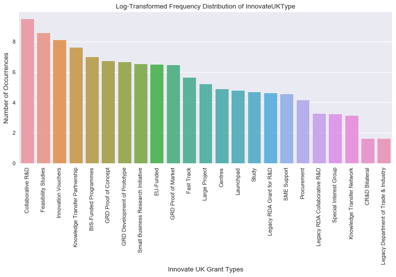

```python
#Print frequency of each value in the innovate uk type column and how many types there are
print('There are', grants_wo_outliers.InnovateUKType.value_counts().count(), 'different innovate uk grant types')
print(grants_wo_outliers.InnovateUKType.value_counts())

#Plot a barchart but with counts log transformed due to  a left hand skew
#The transformation makes it easier to see the differences between the different types
fig=plt.figure(figsize=(12,5), dpi=80, facecolor='w', edgecolor='k')
sns.barplot(type_count.apply(np.log).index, type_count.apply(np.log).values, alpha=0.9)
plt.xticks(rotation='vertical')
plt.title('Log-Transformed Frequency Distribution of InnovateUKType')
plt.ylabel('Number of Occurrences', fontsize=12)
plt.xlabel('Innovate UK Grant Types', fontsize=12)
plt.show()
```

## Sector Counts

```
Emerging & Enabling          13039
Manufacturing & Materials     6398
Infrastructure Systems        4425
Health & Life Science         3374
Non Core                      1730
Development                    334
Name: Sector, dtype: int64
```

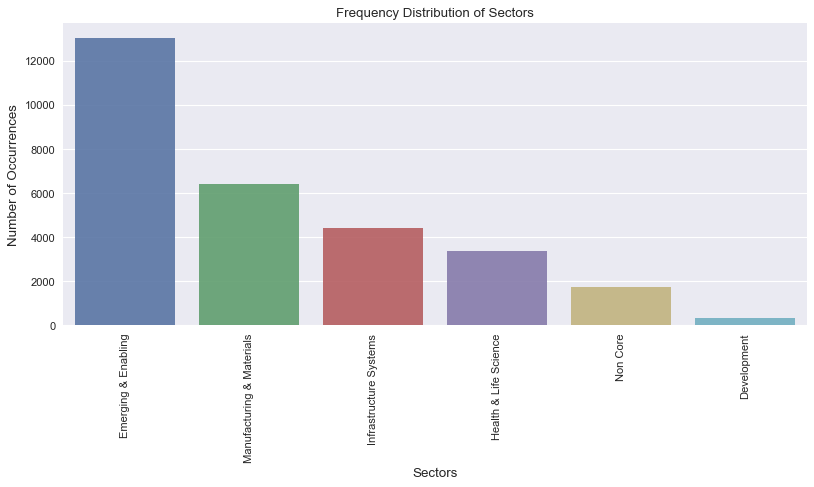

```python
#Print the value counts for the sector column
sector_count = grants_wo_outliers['Sector'].value_counts()
print(sector_count)

#Plot a barchart of these value counts
fig=plt.figure(figsize=(12,5), dpi=80, facecolor='w', edgecolor='k')
sns.set(style="darkgrid")
sns.barplot(sector_count.index, sector_count.values, alpha=0.9)
plt.xticks(rotation='vertical')
plt.title('Frequency Distribution of Sectors')
plt.ylabel('Number of Occurrences', fontsize=12)
plt.xlabel('Sectors', fontsize=12)
plt.show()
```

## Address Region: Sum of Grant Offered by Region

```python
#Print how many projects have a specific address region
region_count = grants_wo_outliers['AddressRegion'].value_counts()
print(region_count)
```

```
London                      5019
South East                  4825
East of England             3201
North West                  2573
South West                  2515
West Midlands               2305
East Midlands               2270
Scotland                    2053
Yorkshire and The Humber    1995
North East                  1112
Wales                        929
Northern Ireland             429
Outside UK                    74
Name: AddressRegion, dtype: int64
```

[figure not shown]

## Enterprise Size Counts

```
Micro                        7358
Academic                     5658
Small                        5286
Large                        5006
Unknown                      3083
Medium                       1982
RTO                           276
PSO                           246
Catapult                      201
Charity                       113
PSRE                           39
Non UK                         22
Micro/Small                    10
Sole Trader                     6
Start-Up                        5
CIC                             5
Private Sector                  1
SME                             1
Eligible for 100% funding       1
Partnership                     1
Name: EnterpriseSize, dtype: int64
```

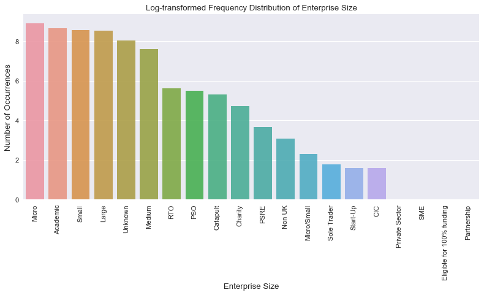

```python
#print the value counts for the feature enterprise size
print(grants_wo_outliers['EnterpriseSize'].value_counts())

## Barchart of enterprise size counts with a log transformation
%matplotlib inline
size_count = grants_wo_outliers['EnterpriseSize'].value_counts().apply(np.log)
fig=plt.figure(figsize=(12,5), dpi=80, facecolor='w', edgecolor='k')
sns.set(style="darkgrid")
sns.barplot(size_count.index, size_count.values, alpha=0.9)
plt.xticks(rotation='vertical')
plt.title('Log-transformed Frequency Distribution of Enterprise Size')
plt.ylabel('Number of Occurrences', fontsize=12)
plt.xlabel('Enterprise Size', fontsize=12)
plt.show()
```

## Withdrawn Status and ProjectStatus

The contents of the withdrawn status and project status columns were analyzed and it was discovered that they contained updates aboubt a project's status after it had recieved grant money. As they are features that do not inform how much money each project will recieve, they were removed them from the dataset because they will not help to aid in predicting the amount of grant money offered by Innovate UK.

```python
#Print the counts of the different values in the project status column
print("Project Status Counts: \n", grants_wo_outliers['ProjectStatus'].value_counts())
print("\n")

#Print the counts of the different values in the withdrawn status column
print("Withdrawn Status Counts: \n", grants_wo_outliers['WithdrawnStatus'].value_counts())

#Drop the withdrawn status and project status columns from the dataframe
grants_wo_outliers = grants_wo_outliers.drop(['WithdrawnStatus', 'ProjectStatus'], axis=1)
```

```
Project Status Counts:
 Closed               21825
Live                  5922
Final Claim           1171
Withdrawn              287
On Hold                 90
Offer Letter Sent        5
Name: ProjectStatus, dtype: int64


Withdrawn Status Counts:
 Active       28745
Withdrawn      555
Name: WithdrawnStatus, dtype: int64
```

# Feature Engineering

Beside the bined grant value column, two other new features based on the provided columns were generated. The first was the duration of the project in years, to make the dates into it a variable that could be used in a machine learning algorithm. This was created by subtracting the end date year from the start date year. Some projects were only a few months long and thus a zero value because they do not run for a full year.

The second was the ratio of grant offered to total cost, which was calculated by dividing a project's grant offered value by its total cost. This column was generated because my hypothesis is that the total cost of the project is the largest determinate for the amount of grant money a project is given. Analyzing the descriptive statistics of the grant ratios let me see that a ratio of one, meaning that the cost and grant offered are equal, is the most common ratio value and makes up 25% of the value counts (as it is in the third quantile). This can also be visualized in how the histogram distributions of grant value and total cost mirror each other and in a color coded scatter plot of cost vs grant value which is colored by the grant ratio. This insight indicates that total cost may be the largest factor in predicting grant offered values. The ratio could also be used to verify and evalidate any predicted grant offered values generated by a machine learner.

```python
#Create a new feature project duration in years based on the start and end date written in the project's application
grants_wo_outliers['ProjectDurationYears'] = grants_wo_outliers['EndDate'].dt.year - grants_wo_outliers['StartDate'].dt.year

#Print the value counts of project duration years to see the spread
print("Project Duration Value Counts: \n", grants_wo_outliers['ProjectDurationYears'].value_counts() )

#It is important to note that there are very are only four projects with a duration longer than 6 years!
```

```
Project Duration Value Counts:
 1    9125
2    7267
3    6004
0    4730
4    1800
5     325
6      45
7       2
9       1
8       1
Name: ProjectDurationYears, dtype: int64
```

```
Mean Grant Ratio: 0.6855029282127211
Median Grant Ratio: 0.6699997837708269
Mode: 0    1.0
dtype: float64
Min: 0.004473892853097746
Max: 1.0
Quantiles: 0.10    0.40
0.25    0.50
0.50    0.67
0.75    1.00
0.90    1.00
Name: GrantRatio, dtype: float64
```

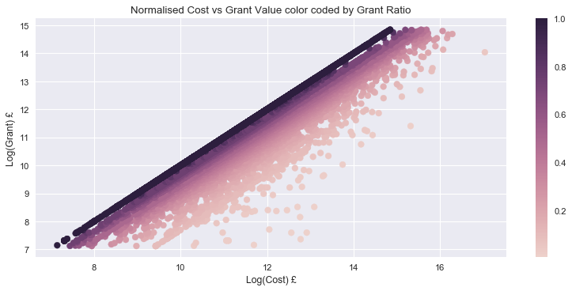

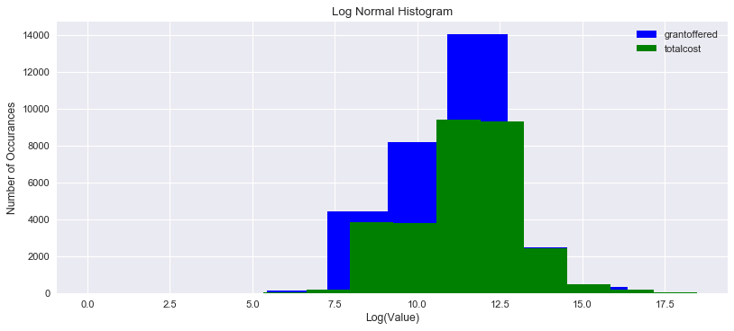

```python
#Create a new feature grant ratios by creating a new column based on the calculation grant offered / total cost
grants_wo_outliers['GrantRatio'] = grants_wo_outliers.apply(lambda row: row.GrantOffered / row.TotalCost, axis = 1)


#print the descriptive statistics about the grant ratio values
print('Mean Grant Ratio:', grants_wo_outliers['GrantRatio'].mean())
print('Median Grant Ratio:', grants_wo_outliers['GrantRatio'].median())
print('Mode:',grants_wo_outliers['GrantRatio'].mode())
print('Min:', grants_wo_outliers['GrantRatio'].min())
print('Max:', grants_wo_outliers['GrantRatio'].max())
print('Quantiles:', grants_wo_outliers['GrantRatio'].quantile(q = [0.10, 0.25,0.5,0.75,0.9]))
print("\n")


#creating a scatter plot of normalised total cost vs normalised grant offered
#with the data-points color coded by their grant ratio (grant/cost)

cmap = sns.cubehelix_palette(as_cmap=True)
f, ax = plt.subplots(figsize=(12,5), dpi=80, facecolor='w', edgecolor='k')
points = ax.scatter(grants_wo_outliers['NormalisedCost'], grants_wo_outliers['NormalisedGrants'],
                    c=grants_wo_outliers['GrantRatio'], s=50, cmap=cmap)
plt.title('Normalised Cost vs Grant Value color coded by Grant Ratio')
plt.xlabel('Log(Cost) £')
plt.ylabel('Log(Grant) £')
f.colorbar(points)
plt.show()

#Visualize the distributions of grant offered and total cost values which have
#both been log transformed
#notice they nearly mirror each other
fig=plt.figure(figsize=(12,5), dpi=80, facecolor='w', edgecolor='k')
plt.hist(grants['NormalisedGrants'], label='grantoffered', color = 'blue')
plt.hist(grants['NormalisedCost'], label='totalcost', color = 'green')
plt.xlabel('Log(Value)')
plt.ylabel('Number of Occurances')
plt.title('Log Normal Histogram')
plt.legend(loc='upper right')
plt.show()
```

```python
#grants_wo_outliers.to_csv('Data_clean.csv', columns = ['ProjectNumber', 'ProjectTitle', 'ProgrammeTitle', 'CompetitionYear', 'Sector' ,
 #                                                      'PublicDescription',
  #                                      'InnovateUKType', 'ParticipantName', 'IsLeadParticipant', 'ProjectDurationYears',
   #                                                 'GrantOffered', 'GrantBins', 'TotalCost', 'GrantRatio', 'ActualSpend',
    #                                               'EnterpriseSize', 'AddressRegion', 'ISCF', 'NormalisedGrants', 'NormalisedCost']
     #                     , index = False)
```

# Random Forest: predicting grant bin

After data cleaning and feature engineering, the resulting dataframe contained 29,300 rows with 21 feature columns. Only 8 of these columns contained numerical data while the rest contained cateorgical data. To solve the analytical task of predicting the amount of grant money a project will recieve, a random forest classification algorithm was used to predict the classes in the "Grant Bins" column. The randomForest package in R can generate random forests using cateogrical data without the need for one-hot-encoding. This removes the tedious step of creating dummy variables from my workflow and should help to improve the accuracy of my model as any structures in the cateogrical data will not be diluted and the categorical features will not be given a lesser importance than any continuous variabels due to the resulting sparsity of one-hot-encoding (Dingwall and Potts, 2018)). The 'important features' table that Random Forests produce was another reason the algorithm is used as it allows for the easy identification of which variables, and even which levels within those categorical variables, are most important in prediction.

The training and testing of the Random Forest model can be found at https://smcse.city.ac.uk/student/aczh498/inm430/Grant_Prediction_R.html which shows a jupyter notebook which runs on an R kernel.

# Investigating the Most Important Features.

The variabels of importance plot generated by a random forest ranks which factors are the most important, but it does not tell you how these features affect the outcome. To investigate the exact impact of the most important feature, total cost, a simple linear regression model was created. Then, to investigate the effects of the top three features, a multi-variable linear regression was calculated using total cost, proejct duration in years and enterprise size.

[figure not shown]

## Linear Regression on Total Cost

### Correlation between total cost and grant offered

Before generating the regression model, a Pearson and Spearman correlation test was generated to see how strong the relationship is between the grant offered and total cost value of a project. The scatterplot of these two variables, seen in the outlier detection section, shows that most of the data follows a linear relationship. Therefore, a Pearson correlation test should be the correct analysis measure needed, however I calculated both to ensure a hollistic analysis was conducted.

The Pearson correlation value was 0.96 with a p-value of 0.0 and the Spearman correlation value was 0.95 with a p-value of 0.0. As suspected the Pearson was able to capture the relationship, and even generate a higher correlation value, then the Spearman correlation test due to the strong linearity of the data. A zero p-value is due to rounding but it indicates that the correlation has a strong statistical significance.

```python
## The follow is all based on PDS Tutorial Week 4

#generate a numpy array for the grant and cost values to use for the correlation tests
numpyArray = grants_wo_outliers.as_matrix(['NormalisedGrants', "NormalisedCost"])
grant = numpyArray[:,0]
cost = numpyArray[:,1]

#Pearson Correlation Test
corrPearson, pVal1 = stats.pearsonr(cost,grant)
print ("Pearson Correlation: ", corrPearson, pVal1)

#Spearman Correlation Test
corrSpearman, pVal2 = stats.spearmanr(cost, grant)
print ("Spearman Correlation: ", corrSpearman, pVal2)
```

```
Pearson Correlation:  0.9584313659829556 0.0
Spearman Correlation:  0.9548669945534973 0.0
```

```
Slope:  0.896085499311009
Intercept:  0.7255202124043834
p_value:  0.0
std_err:  0.001558498895379165
R^2 value:  0.9584313659829563
```

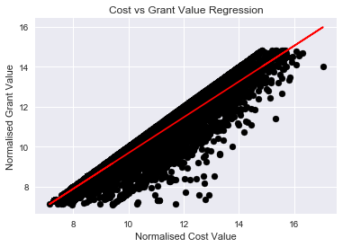

```python
#Using the numpy arrays generated of the normalised grant and normalised cost columns during the above correlation
#use the scipy library to generate a linear regression
#and save the slope, intercept, r-squared, p-value and standard error
slope, intercept, r_value, p_value, std_err = stats.linregress(cost, grant)

#print these saved values generated by the linear regresion
print ("Slope: ", slope)
print ("Intercept: ", intercept)
print ("p_value: ", p_value)
print ("std_err: ", std_err)
print ("R^2 value: ", r_value)


# Use the polyval function to evaluate our model over the whole set of data points by running y=m*x + b for
#each cost data-point
evaluatedLine = np.polyval([slope, intercept], cost)

#Visualize the model on a scatter plot of cost vs grant value as a red line
plt.scatter(grants_wo_outliers.NormalisedCost, grants_wo_outliers.NormalisedGrants, color = 'black')
plt.plot(grants_wo_outliers.NormalisedCost, evaluatedLine, 'r')
plt.title('Cost vs Grant Value Regression')
plt.xlabel('Normalised Cost Value')
plt.ylabel('Normalised Grant Value')
plt.show()
```

## Multi-variable Linear Regression

### Creating dummy variables to prepare cateogorical data

```python
## Project Duration Years Dummy Variables
#create a dataframe containing the dummy variables for the column 'Project Duration Years'
dummies_years = pd.get_dummies(grants_wo_outliers['ProjectDurationYears'], prefix='years')

#concatonate the dummies dataframe with the rest of the data in grants_wo_outliers
grants_wo_outliers = pd.concat([grants_wo_outliers, dummies_years], axis=1)


##Enterprise Size Dummy Variables
#create a dataframe containing the dummy variables for the column 'Project Duration Years'
dummies_size = pd.get_dummies(grants_wo_outliers['EnterpriseSize'], prefix='size_')

#concatonate the dummies dataframe with the rest of the data in grants_wo_outliers
grants_wo_outliers = pd.concat([grants_wo_outliers, dummies_size], axis=1)

#check that columns are all there
grants_wo_outliers.info()
```

```
<class 'pandas.core.frame.DataFrame'>
Int64Index: 29300 entries, 1850 to 31150
Data columns (total 59 columns):
ProgrammeTitle                     29300 non-null object
Sector                             29300 non-null object
ProjectNumber                      29300 non-null int64
ProjectTitle                       29300 non-null object
PublicDescription                  29300 non-null object
CompetitionYear                    29300 non-null object
InnovateUKType                     29300 non-null object
ParticipantName                    29300 non-null object
IsLeadParticipant                  29300 non-null object
StartDate                          29300 non-null datetime64[ns]
EndDate                            29300 non-null datetime64[ns]
GrantOffered                       29300 non-null float64
TotalCost                          29300 non-null float64
ActualSpend                        29300 non-null float64
EnterpriseSize                     29300 non-null object
AddressRegion                      29300 non-null object
ISCF                               29300 non-null object
NormalisedGrants                   29300 non-null float64
NormalisedCost                     29300 non-null float64
NormalisedSpend                    29299 non-null float64
Outlier1                           29300 non-null int64
Outlier2                           29300 non-null int64
Outlier3                           29300 non-null int64
color1                             29300 non-null object
color2                             29300 non-null object
color3                             29300 non-null object
GrantBins                          29300 non-null object
GrantRatio                         29300 non-null float64
ProjectDurationYears               29300 non-null int64
years_0                            29300 non-null uint8
years_1                            29300 non-null uint8
years_2                            29300 non-null uint8
years_3                            29300 non-null uint8
years_4                            29300 non-null uint8
years_5                            29300 non-null uint8
years_6                            29300 non-null uint8
years_7                            29300 non-null uint8
```

[output cut: 9 more lines]

```
size__Micro                        29300 non-null uint8
size__Micro/Small                  29300 non-null uint8
size__Non UK                       29300 non-null uint8
size__PSO                          29300 non-null uint8
size__PSRE                         29300 non-null uint8
size__Partnership                  29300 non-null uint8
size__Private Sector               29300 non-null uint8
size__RTO                          29300 non-null uint8
size__SME                          29300 non-null uint8
size__Small                        29300 non-null uint8
size__Sole Trader                  29300 non-null uint8
size__Start-Up                     29300 non-null uint8
size__Unknown                      29300 non-null uint8
dtypes: datetime64[ns](2), float64(7), int64(5), object(15), uint8(30)
memory usage: 8.8+ MB
```

```python
#Make an array of the predictor variables of interest
predictors = grants_wo_outliers.as_matrix(['NormalisedCost','years_0','years_1','years_2', 'years_3', 'years_4', 'years_5', 'years_6',
                                'years_7', 'years_8', 'years_9', 'size__Academic', 'size__CIC',
                               'size__Catapult','size__Eligible for 100% funding', 'size__Large', 'size__Medium',
                                'size__Micro', 'size__Micro/Small',
                               'size__Non UK', 'size__PSO', 'size__Partnership', 'size__Private Sector',
                                'size__RTO', 'size__SME', 'size__Small','size__Sole Trader','size__Start-Up',
                                'size__Unknown'])

# Use the OLS function from statsmodels to model grant values using the predictors
model = sm.OLS(grant,predictors)
#fit the model
results = model.fit()

# Print the summary report of the model
print ("Params: ", results.summary())
```

```
Params:                              OLS Regression Results
==============================================================================
Dep. Variable:                      y   R-squared:                       0.944
Model:                            OLS   Adj. R-squared:                  0.944
Method:                 Least Squares   F-statistic:                 1.766e+04
Date:                Sun, 16 Dec 2018   Prob (F-statistic):               0.00
Time:                        12:05:09   Log-Likelihood:                -10319.
No. Observations:               29300   AIC:                         2.070e+04
Df Residuals:                   29271   BIC:                         2.094e+04
Df Model:                          28
Covariance Type:            nonrobust
==============================================================================
                 coef    std err          t      P>|t|      [0.025      0.975]
------------------------------------------------------------------------------
x1             0.9522      0.002    571.197      0.000       0.949       0.955
x2             0.5143      0.032     15.917      0.000       0.451       0.578
x3             0.4284      0.033     13.036      0.000       0.364       0.493
x4             0.2697      0.034      7.987      0.000       0.203       0.336
x5             0.2124      0.034      6.226      0.000       0.146       0.279
x6             0.1573      0.035      4.510      0.000       0.089       0.226
x7             0.1467      0.039      3.747      0.000       0.070       0.223
x8             0.2825      0.062      4.592      0.000       0.162       0.403
x9             0.1155      0.246      0.469      0.639      -0.367       0.598
x10            0.7397      0.346      2.137      0.033       0.061       1.418
x11            0.9935      0.346      2.872      0.004       0.315       1.672
x12            0.0759      0.028      2.678      0.007       0.020       0.131
x13           -0.2109      0.157     -1.348      0.178      -0.518       0.096
x14            0.2884      0.037      7.776      0.000       0.216       0.361
x15            0.0853      0.345      0.247      0.805      -0.592       0.762
x16           -0.5422      0.028    -19.076      0.000      -0.598      -0.486
x17           -0.4382      0.029    -15.092      0.000      -0.495      -0.381
x18           -0.2861      0.028    -10.104      0.000      -0.342      -0.231
x19           -0.0336      0.112     -0.299      0.765      -0.254       0.187
x20           -0.0977      0.079     -1.242      0.214      -0.252       0.056
x21            0.1365      0.036      3.842      0.000       0.067       0.206
x22           -0.1337      0.345     -0.387      0.699      -0.811       0.543
x23            0.1991      0.345      0.576      0.564      -0.478       0.876
x24            0.1442      0.035      4.145      0.000       0.076       0.212
x25           -0.2570      0.345     -0.744      0.457      -0.934       0.420
x26           -0.3462      0.028    -12.199      0.000      -0.402      -0.291
x27           -0.3284      0.143     -2.291      0.022      -0.609      -0.047
x28            0.0258      0.157      0.165      0.869      -0.281       0.333
x29           -0.1392      0.029     -4.847      0.000      -0.195      -0.083
==============================================================================
Omnibus:                    16176.257   Durbin-Watson:                   1.427
Prob(Omnibus):                  0.000   Jarque-Bera (JB):           239931.008
Skew:                          -2.341   Prob(JB):                         0.00
Kurtosis:                      16.214   Cond. No.                     2.02e+03
==============================================================================

Warnings:
[1] Standard Errors assume that the covariance matrix of the errors is correctly specified.
[2] The condition number is large, 2.02e+03. This might indicate that there are
strong multicollinearity or other numerical problems.
```

# Further analysis of other features

To see the relationship of the other features used in the random forest model, stacked percentage barcharts were generated of the proportion of each feature's levels within a grant bin class. Across the different features the proportions are pretty consistent between the different grant bin classes. This is probably why they contribute such a small amount to the random forest classification model because there is not much variance to distinguish the features between classes. The exception to this is the first grant bin class tends to have a different pattern, but this is probably due to the high amount of samples in this class. One important trend to note is that the Innovate UK product type 'Innovate Vouchers' are only present in the first class (and make up most of it proportionally) because Innovate Vouchers are small grants of £5000 given to small firms to seek expert advice on a project, which is a project classified in the 'emerging and enabling' sector. The graphs below were created in Tableau.

[figure not shown]

# Linear Regression Prediction of Grant Offered Value

As the two linear regression models generated showed that the total cost of the project to be the biggest determiner of the grant offered value, I created a linear regression prediction model to test its accuracy and used cross-validation to validate it and make the model more robust. The cross-validation results are very consistent, highlighting how dependent grant value is on cost.

Lastly, I used the model created to predict the grant value offered to the projects which are in the grant_zero data-subset as they had cost figures but no grant offered value.

```
-------- We are having the run:  0
Slope:  0.9062034517018215 Intercept:  0.6105488175512352 r_value:  0.9477774354502303 p_value:  0.0 std_err:  0.001877930498009237
-------- We are having the run:  1
Slope:  0.8928156932282072 Intercept:  0.7879051174076643 r_value:  0.9586420197127752 p_value:  0.0 std_err:  0.0016323901054604263
-------- We are having the run:  2
Slope:  0.8971236936727393 Intercept:  0.7274411479990128 r_value:  0.9603236436081647 p_value:  0.0 std_err:  0.0016044489030012988
-------- We are having the run:  3
Slope:  0.9008429086417264 Intercept:  0.6876057054605429 r_value:  0.9625304656340606 p_value:  0.0 std_err:  0.0015629437076444361
-------- We are having the run:  4
Slope:  0.9012343315833704 Intercept:  0.6705335906703045 r_value:  0.9611077991379359 p_value:  0.0 std_err:  0.001594810272354771
-------- We are having the run:  5
Slope:  0.8997529347058272 Intercept:  0.6822958496826566 r_value:  0.9602624133271648 p_value:  0.0 std_err:  0.001610469844743268
-------- We are having the run:  6
Slope:  0.8984520395578449 Intercept:  0.6931941772731438 r_value:  0.9596617042632032 p_value:  0.0 std_err:  0.0016210166107820528
-------- We are having the run:  7
Slope:  0.8966535242476176 Intercept:  0.7090179909035683 r_value:  0.9590093056613663 p_value:  0.0 std_err:  0.0016316391989400721
-------- We are having the run:  8
Slope:  0.8925238321989847 Intercept:  0.7521813964611983 r_value:  0.9566866744226944 p_value:  0.0 std_err:  0.0016725646373402588
-------- We are having the run:  9
Slope:  0.8617581605088661 Intercept:  1.0765608095240893 r_value:  0.9480017162189865 p_value:  0.0 std_err:  0.001781668323249514
```

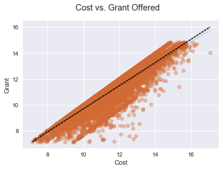

```python
from sklearn import cross_validation

# Plot cost vs grant offered value for the linear regression lines to be plotted on
plt.figure(1)
plt.suptitle('Cost vs. Grant Offered')
plt.xlabel('Cost')
plt.ylabel('Grant')
plt.scatter(arr1, arr2 , c = "#D06B36", s = 50, alpha = 0.4, linewidth='0')


#using the numpy arrays generated in the first linear regression model
#train a 10-fold cross validation linear regression model
#and each folds statistics (slope, intercept, r-squared value and p-value and standard error)
#to ensure the model is robust and consistent

numberOfSamples = len(grant)
kf = cross_validation.KFold(numberOfSamples, n_folds=10)
foldCount = 0

for train_index, test_index in kf:
    print("-------- We are having the run: ", foldCount )
    arraySubset1 = cost[train_index]
    arraySubset2 = grant[train_index]
    slope, intercept, r_value, p_value, std_err = stats.linregress(arraySubset1, arraySubset2)

    print ("Slope: ", slope, "Intercept: ", intercept, "r_value: ", r_value, "p_value: ", p_value,"std_err: ", std_err)

    xp = np.linspace(arr1.min(), arr1.max(), 100)
    evaluatedLine = np.polyval([slope, intercept], xp)
    # let's see a black line overlaid on the data
    # for each run, we draw a line again
    plt.plot(xp, evaluatedLine, 'k--', linewidth = 1, alpha = 0.3)
    foldCount += 1
```

```python
#Now, test the accuracy of the model on unseen data
#by spliting the dataset into a training and testing set
#and then printing the mean difference betweeen the estimate and the real value

#as well using the arrays generated in the first linear regression model

for train_index, test_index in kf:
    print("-------- We are having the run: ", foldCount )
    arraySubset1 = cost[train_index]
    arraySubset2 = grant[train_index]

    unseenSubset1 = cost[test_index]
    unseenSubset2 = grant[test_index]

    slope, intercept, r_value, p_value, std_err = stats.linregress(arraySubset1, arraySubset2)

    # Use the regression models to estimate the unseen grant offered value given the total cost value
    estimatedValues = slope * unseenSubset1 + intercept

    # check the difference between the estimates and the real values
    differences = unseenSubset2 - estimatedValues
    print ('Difference:', np.average(differences))
    print ('UnNormalised Difference (£):', np.exp(np.average(differences)))
    print('R-squared:', r_value)
    foldCount += 1
```

```
-------- We are having the run:  20
Difference: -0.0032009402493016364
UnNormalised Difference (£): 0.9968041772981607
R-squared: 0.9477774354502303
-------- We are having the run:  21
Difference: -0.251262980176254
UnNormalised Difference (£): 0.7778177939996556
R-squared: 0.9586420197127752
-------- We are having the run:  22
Difference: -0.13750895757063064
UnNormalised Difference (£): 0.8715265432016257
R-squared: 0.9603236436081647
-------- We are having the run:  23
Difference: -0.1629495992802687
UnNormalised Difference (£): 0.8496340095010615
R-squared: 0.9625304656340606
-------- We are having the run:  24
Difference: -0.036830098015560545
UnNormalised Difference (£): 0.9638398797466613
R-squared: 0.9611077991379359
-------- We are having the run:  25
Difference: 0.014348710636426176
UnNormalised Difference (£): 1.014452147521409
R-squared: 0.9602624133271648
-------- We are having the run:  26
Difference: 0.053599121442051846
UnNormalised Difference (£): 1.0550615658085971
R-squared: 0.9596617042632032
-------- We are having the run:  27
Difference: 0.10029722112408922
UnNormalised Difference (£): 1.105499447038684
R-squared: 0.9590093056613663
-------- We are having the run:  28
Difference: 0.13923104974456207
UnNormalised Difference (£): 1.149389635508155
R-squared: 0.9566866744226944
-------- We are having the run:  29
Difference: 0.4011068002161294
UnNormalised Difference (£): 1.4934767636238908
R-squared: 0.9480017162189865
```

```python
# Predicting grant offered values on the projects which had a zero value for grant offered
#Using the grants_zero data-subset

for train_index, test_index in kf:
    print("-------- We are having the run: ", foldCount )
    arraySubset1 = cost[train_index]
    arraySubset2 = grant[train_index]

    zero_valued_costs = grants_zero.NormalisedCost

    #generate the model
    slope, intercept, r_value, p_value, std_err = stats.linregress(arraySubset1, arraySubset2)

    # Use the regression models to estimate the grant offered values given the cost value
    estimatedValues = slope * zero_valued_costs + intercept

    # Print the estimated values and the R-squared value
    print(estimatedValues)
    print('R:', r_value)
    foldCount += 1

#Notice, still getting high R-squared values between 0.95 and 0.96!!
```

```
-------- We are having the run:  40
1       10.208463
11       9.889874
12       9.365873
13       9.409036
14       9.324425
15       9.324425
16      11.469521
17      10.135155
18      11.772327
19      11.631431
20      11.226323
21      12.863210
22      13.296538
25      11.976646
```

[output cut: 625 more lines]

# Investigating Project Titles

Before we can analyze the project titles, they need to under go some data processing. The first is spliting the titles by space into a list of words. The first insight I looked into was the value counts for the amount of words in a title. Most projects have only 7 words, with 8 and 6 words being in second and third place. The final edited titles were edited to be all lower case, have puncuation removed, have stop words removed, and any numbers removed.

Word frequency lists and word clouds were then generated on all the project titles and then the project titles split by sector.

```python
from textblob import TextBlob
# code inspiration from https://www.analyticsvidhya.com/blog/2018/02/the-different-methods-deal-text-data-predictive-python/

#make a new column with the word count of ProjectTitles
grants_wo_outliers['word_count_title'] = grants_wo_outliers['ProjectTitle'].apply(lambda x: len(str(x).split(" ")))

#print the first 10 project titles and what their word count is
print(grants_wo_outliers[['ProjectTitle','word_count_title']].head(n=10))
print('\n')

#print the different values inside the word count column and their counts
print("Word-Count Counts: \n", grants_wo_outliers['word_count_title'].value_counts())
```

```
                                           ProjectTitle  word_count_title
1850  Microbial Management of Fresh Produce: Preserv...                 9
1851            Non firing repairs of vitreous surfaces                 6
1852  An Integrated Sensor System for Combustion Pla...                 8
1853  New biofumigation-based approaches to sustaina...                 9
1854     CO2ENT: ENTRAPMENT OF CARBON DIOXIDE FOR REUSE                 7
1855  Trainable Vision-based Anomaly Detection and D...                 6
1856  Synthesis of cyclic carbonates from power stat...                 9
1857         Micro-Porous Metals for Thermal Management                 5
1858  Using macro environmental data to support long...                29
1859          Circular Design for an Economy Power Tool                 7


Word-Count Counts:
 7     3099
```

[output cut: 41 more lines]

```python
#Notice there are 1 worded project titles and was curious to know what these were

#filter the rows where word count title equals 1 and print the project title
grants_wo_outliers[grants_wo_outliers['word_count_title']==1]['ProjectTitle'].head(n=15)

#Notice that these are usual just names of the product going to be created in the resarch
```

```
1981     SafetyNet
1993      SAFEMOVE
2017         AEGIS
2019    Contaminal
2038      FOOTLITE
2065    Zerowaster
2066         3GRSE
2070           PIM
2087      VENTURER
2093      HiPerPol
2106       HAVEMOR
2193      OPTISORT
2194        SPRINT
2196      RoChemOx
2200      Airpower
Name: ProjectTitle, dtype: object
```

```python
#Print the 15 most common occur words in all the project titles
freq = pd.Series(' '.join(grants_wo_outliers['ProjectTitle']).split()).value_counts()[:15]

print(freq)

#notice that most of these words are "stop words" and are not informative of the actual content in the project title
```

```
of             8488
for            8336
and            7299
-              3396
the            2860
to             2352
in             2293
University     1969
a              1913
Limited        1858
Development    1288
&              1053
The            1034
High            880
A               867
dtype: int64
```

```python
#Count the number of stop words in each title
from nltk.corpus import stopwords

stop = stopwords.words('english')

grants_wo_outliers['stopwords'] = grants_wo_outliers['ProjectTitle'].apply(lambda x: len([x for x in x.split() if x in stop]))

#print the first 4 projct titiles and the count of stop words in them
grants_wo_outliers[['ProjectTitle','stopwords']].head()
```

|  | ProjectTitle | stopwords |
| --- | --- | --- |
| 1850 | Microbial Management of Fresh Produce: Preserv... | 1 |
| 1851 | Non firing repairs of vitreous surfaces | 1 |
| 1852 | An Integrated Sensor System for Combustion Pla... | 1 |
| 1853 | New biofumigation-based approaches to sustaina... | 2 |
| 1854 | CO2ENT: ENTRAPMENT OF CARBON DIOXIDE FOR REUSE | 0 |

```python
#Create a new column which will contain the edited versions of the project titles
grants_wo_outliers['TitleEdited'] = grants_wo_outliers['ProjectTitle']

## Processing of the project titles to make them useful for analysis

#Step 1: make all the words lower case
grants_wo_outliers['TitleEdited'] = grants_wo_outliers['TitleEdited'].apply(lambda x: " ".join(x.lower() for x in x.split()))

#Step 2: remove puncuation from the titles
grants_wo_outliers['TitleEdited'] = grants_wo_outliers['TitleEdited'].str.replace('[^\w\s]','')

#step 3: remove numbers
from string import digits
remove_digits = str.maketrans('', '', digits)
grants_wo_outliers['TitleEdited'] = grants_wo_outliers['TitleEdited'].str.translate(remove_digits)

#Step 4: remove stop words
grants_wo_outliers['TitleEdited'] = grants_wo_outliers['TitleEdited'].apply(lambda x: " ".join(x for x in x.split() if x not in stop))

#see changes
print(grants_wo_outliers['TitleEdited'].head())
print('\n')

#Print the 20 most frequently used words in the edited project titles
print("20 most used words:\n", pd.Series(' '.join(grants_wo_outliers['TitleEdited']).split()).value_counts()[:20])
```

```
1850    microbial management fresh produce preservatio...
1851                 non firing repairs vitreous surfaces
1852    integrated sensor system combustion plant opti...
1853    new biofumigationbased approaches sustainable ...
1854                coent entrapment carbon dioxide reuse
Name: TitleEdited, dtype: object


20 most used words:
 university       1975
limited          1898
development      1636
system           1443
novel            1353
energy           1272
high             1269
technology       1122
using             997
systems           832
advanced          800
integrated        799
low               782
manufacturing     778
monitoring        763
production        730
management        661
project           643
technologies      626
platform          614
dtype: int64
```

# Creating word clouds

```python
from os import path
from PIL import Image
from wordcloud import WordCloud, STOPWORDS, ImageColorGenerator

import matplotlib.pyplot as plt
% matplotlib inline

#Code inspiration taken from  https://www.datacamp.com/community/tutorials/wordcloud-python
```

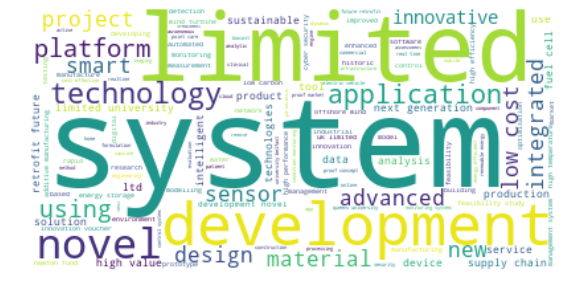

```python
## Generate a word cloud image for all the project titles in the dataset

#Combine all the project titles into one text
text_title = " ".join(title for title in grants_wo_outliers.TitleEdited)

#generate the wordcloud image
wordcloud = WordCloud(stopwords=stop, background_color="white").generate(text_title)

# Display the generated image the matplotlib way:
plt.figure(figsize=(15, 5), dpi=70, facecolor='w', edgecolor='k')
plt.imshow(wordcloud, interpolation='bilinear')
plt.axis("off")
plt.show()
```

```python
#Generate word frequency lists for each sector

#create a list of the sector names to use for filtering
sectors = ['Emerging & Enabling', 'Manufacturing & Materials', 'Infrastructure Systems',
          'Non Core', 'Development']

#Generate and print the word frequencies for a sector
#by first subsetting the rows for only the specified sector and then spliting the words by space and generating value
#counts for each word
#and repeating for each sector
emerging_titles = grants_wo_outliers[grants_wo_outliers['Sector'] == (sectors[0])]['TitleEdited']
print("Emerging & Enabling Sector Top 10 Words: \n", pd.Series(' '.join(emerging_titles).split()).value_counts()[0:10])
print('\n')

manufacturing_titles = grants_wo_outliers[grants_wo_outliers['Sector'] == (sectors[1])]['TitleEdited']
print("Manufacturing & Materials Sector Top 10 Words: \n", pd.Series(' '.join(manufacturing_titles).split()).value_counts()[:10])
print('\n')

infrastructure_titles = grants_wo_outliers[grants_wo_outliers['Sector'] == (sectors[2])]['TitleEdited']
print("Infrastructure Systems Sector Top 10 Words: \n", pd.Series(' '.join(infrastructure_titles).split()).value_counts()[:10])
print('\n')

non_core_titles = grants_wo_outliers[grants_wo_outliers['Sector'] == (sectors[3])]['TitleEdited']
print("Non Core Sector Top 10 Words: \n", pd.Series(' '.join(non_core_titles).split()).value_counts()[:10])
print('\n')

development_titles = grants_wo_outliers[grants_wo_outliers['Sector'] == (sectors[4])]['TitleEdited']
print("Development Sector Top 10 Words: \n", pd.Series(' '.join(development_titles).split()).value_counts()[:10])
```

```
Emerging & Enabling Sector Top 10 Words:
 university     1912
limited        1831
development     569
system          540
technology      448
data            385
novel           375
ltd             357
high            352
using           290
dtype: int64


Manufacturing & Materials Sector Top 10 Words:
 high             521
manufacturing    450
development      368
novel            357
materials        327
advanced         310
energy           291
using            280
technology       270
lightweight      265
dtype: int64


Infrastructure Systems Sector Top 10 Words:
 energy        649
system        372
monitoring    265
retrofit      258
future        245
low           233
using         214
power         201
management    196
integrated    194
dtype: int64
```

[output cut: 13 more lines]

```
dtype: int64


Development Sector Top 10 Words:
 fund           142
newton         142
network         33
eniw            27
een             27
development     25
programme       21
sga             21
europe          20
enterprise      20
dtype: int64
```

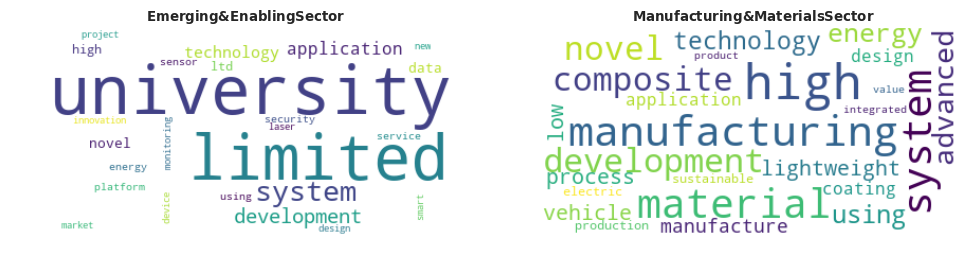

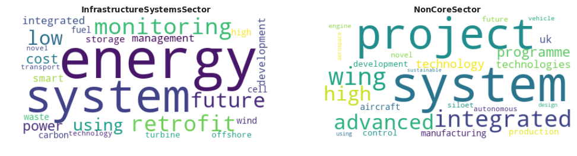

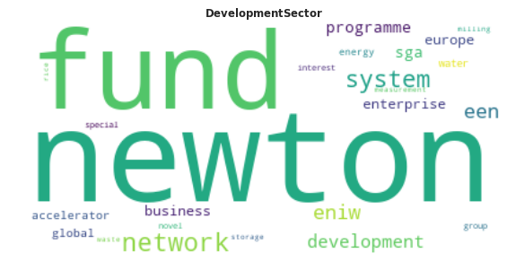

```python
## Generate Word clouds for each sector using the same process as above to generate a cloud for all project titles

#Word Cloud for the emerging and enabling sector
emerg_title = " ".join(word for word in emerging_titles)
wordcloud = WordCloud(stopwords=stop, background_color="white",
                      max_words = 25, relative_scaling=1, collocations=False).generate(emerg_title)
plt.figure(figsize=(15, 5), dpi=80, facecolor='w', edgecolor='k')
plt.subplot(1,2,1)
plt.imshow(wordcloud, interpolation='bilinear')
plt.title(r"$\bf{Emerging & Enabling Sector}$")
plt.axis("off")

#Word Cloud for the manufactoring & materials sector
manu_title = " ".join(word for word in manufacturing_titles)
wordcloud = WordCloud(stopwords=stop, background_color="white",
                      max_words = 25, relative_scaling=1, collocations=False).generate(manu_title)
plt.subplot(1,2,2)
plt.imshow(wordcloud, interpolation='bilinear')
plt.title(r"$\bf{Manufacturing & Materials Sector}$")
plt.axis("off")
plt.show()

#Word cloud for the infrastucture systems sector
infra_title = " ".join(word for word in infrastructure_titles)
wordcloud = WordCloud(stopwords=stop, background_color="white",
                      max_words = 25, relative_scaling=1, collocations=False).generate(infra_title)
plt.figure(figsize=(15, 5), dpi=80, facecolor='w', edgecolor='k')
plt.subplot(1,2,1)
plt.imshow(wordcloud, interpolation='bilinear')
plt.title(r"$\bf{Infrastructure Systems Sector}$")
plt.axis("off")

#Word cloud for the non-core sector
non_title = " ".join(word for word in non_core_titles)
wordcloud = WordCloud(stopwords=stop, background_color="white",
                      max_words = 25, relative_scaling=1, collocations=False).generate(non_title)
plt.subplot(1,2,2)
plt.imshow(wordcloud, interpolation='bilinear')
plt.title(r"$\bf{Non Core Sector}$")
plt.axis("off")
plt.show()

#Word cloud for the development sector
dev_title = " ".join(word for word in development_titles)
wordcloud = WordCloud(stopwords=stop, background_color="white",
                      max_words = 25, relative_scaling=1, collocations=False).generate(dev_title)
plt.figure(figsize=(15, 5), dpi=70, facecolor='w', edgecolor='k')
plt.imshow(wordcloud, interpolation='bilinear')
plt.title(r"$\bf{Development Sector}$")
plt.axis("off")
plt.show()
```